# Bike Sharing Demand Prediction

Fig_2 : There is also high demand in peak hours at 8 AM and also between !7 – 18 PM

Fig_3 : we exclude year variable because of limited 2 year data

Fig_4 : There is no affect of weekday on demand factor

Fig_5 : There is high demand of bicycle in summer months

Fig_6 : Demand decreases as change in weather as if it is light rain , heavy rain , foggy demand decreases.

Fig_7 : excluding working day as it also does not affect that much

Fig_8 : There is high demand on non holiday days

We exclude windspeed ,weekday , year , workingday

```python
#Drop the required variable
bikes_prep = bikes_prep.drop(['weekday','year','workingday'],axis = 1)
```

```python
#Step 3 - Checking Multiple Linear Regression Assumption
#Linearity using correlation coefficient matrix using
correlation=bikes_prep[['temp','atemp','humidity','windspeed','demand']].corr()
correlation
```

|  | temp | atemp | humidity | windspeed | demand |
| --- | --- | --- | --- | --- | --- |
| temp | 1.000000 | 0.987672 | -0.069881 | -0.023125 | 0.404772 |
| atemp | 0.987672 | 1.000000 | -0.051918 | -0.062336 | 0.400929 |
| humidity | -0.069881 | -0.051918 | 1.000000 | -0.290105 | -0.322911 |
| windspeed | -0.023125 | -0.062336 | -0.290105 | 1.000000 | 0.093234 |
| demand | 0.404772 | 0.400929 | -0.322911 | 0.093234 | 1.000000 |

There is high correlation between temp and atemp so we exclude the atemp feature And also there is no high impact of windspeed on demand variable so we are going to excldue it

```python
#Dropping the correlated varibale
bikes_prep = bikes_prep.drop(['atemp','windspeed'],axis = 1)
```

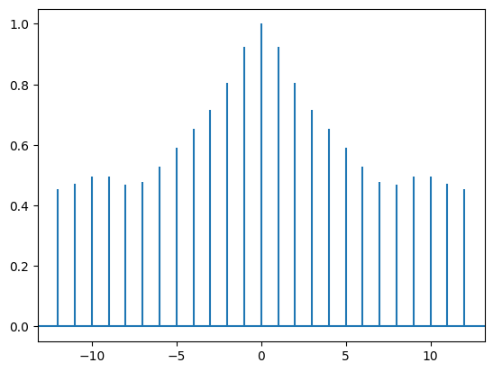

```python
# Chek the autocorrelation in demand using corr
df1 = pd.to_numeric(bikes_prep['demand'],downcast='float')
plt.acorr(df1,maxlags=12)
```

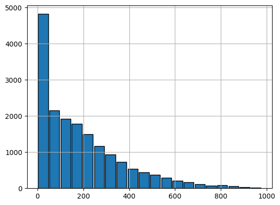

```python
#Solving the assumption of normality
df1 = bikes_prep['demand']
df1.hist(rwidth=0.9,edgecolor='black',bins=20)
```

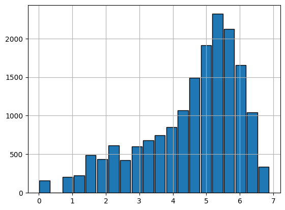

```python
 #lognormlaize the feature demand
df2 = np.log(df1)
df2.hist(rwidth=0.9,edgecolor='black',bins=20)
```

Now demand variable shows the normal distrubution tendancy

```python
#Taking log of demand variable
bikes_prep['demand'] = np.log(bikes_prep['demand'])
```

```python
#solving the assumption of autocorrelation
t_1 = bikes_prep['demand'].shift(+1).to_frame()
t_1.columns = ['t-1']
t_2 = bikes_prep['demand'].shift(+2).to_frame()
t_2.columns = ['t-2']
t_3 = bikes_prep['demand'].shift(+3).to_frame()
t_3.columns = ['t-3']
```

```python
#rebuilding datasset along the lagged variables to tackle autocorrelation
bikes_prep_lag = pd.concat([bikes_prep,t_1,t_2,t_3,],axis=1)
bikes_prep_lag = bikes_prep_lag.dropna()
```

```python
#create dummy variables and drop first to avoid dummy variables trap using get_dummies
bikes_prep_lag['season'] = bikes_prep_lag['season'].astype('category')
bikes_prep_lag['holiday'] = bikes_prep_lag['holiday'].astype('category')
bikes_prep_lag['weather'] = bikes_prep_lag['weather'].astype('category')
bikes_prep_lag['month'] = bikes_prep_lag['month'].astype('category')
bikes_prep_lag['hour'] = bikes_prep_lag['hour'].astype('category')
```

```python
bikes_prep_lag = pd.get_dummies(bikes_prep_lag,drop_first=True)
```

```python
# Train Test Split
from sklearn.model_selection import train_test_split
#Demand id dependent or time series
Y = bikes_prep_lag['demand']
X = bikes_prep_lag.drop(['demand'],axis=1)
#Create the size for 70 % of the data
tr_size = 0.7*len(X)
tr_size = int(tr_size)
X_train = X.values[0:tr_size]
X_test = X.values[tr_size:len(X)]
Y_train = Y.values[0:tr_size]
Y_test = Y.values[tr_size:len(Y)]
```

```python
#calculating RMSE
from sklearn.linear_model import LinearRegression
std_reg = LinearRegression()
std_reg.fit(X_train,Y_train)
r2_train = std_reg.score(X_train,Y_train)
r2_test = std_reg.score(X_test,Y_test)
Y_predict = std_reg.predict(X_test)
from sklearn.metrics import mean_squared_error
rmse = math.sqrt(mean_squared_error(Y_test,Y_predict))
rmse
```

```
0.3809880049817039
```

```python
#calculating RMSLE
Y_test_e = []
Y_predict_e = []
for i in range(0,len(Y_test)):
    Y_test_e.append(math.exp(Y_test[i]))
    Y_predict_e.append(math.exp(Y_predict[i]))
log_sq_sum = 0.0
for i in range(0,len(Y_test_e)):
    log_a = math.log(Y_test_e[i] + 1)
    log_p = math.log(Y_predict_e[i] + 1)
    log_diff = (log_p - log_a)**2
    log_sq_sum = log_sq_sum + log_diff
    rmsle = math.sqrt(log_sq_sum/len(Y_test))
rmsle
```

```
0.3560941706980206
```